# データ・サイエンス データ・サイエンス社会応用論 / ICT社会応用演習Ⅳ

## 第12回課題

### 課題1

基盤地図情報のライセンスは、講義で扱った通り、一般的な「オープンデータ」のライセンスではない。 一部のデータには「基本測量成果」が含まれており、利用に当たっては測量法に基づく申請が必要。

- https://www.gsi.go.jp/LAW/2930-index.html

以下のような内容をまとめることを想定している。

- https://www.gsi.go.jp/common/000223838.pdf

大まかには、以下のケースがあるので、それらを整理することを想定している。

- 申請不要なケース
- 複製を行うケース: 複製承認申請が必要
- 使用を行なうケース: 使用承認申請が必要

また申請の具体的な手続きは、以下で記載されている。

- https://www.gsi.go.jp/LAW/2930-flow.html

### 課題2

都営バスのGTFSデータは、以下で公開されている。

- https://ckan.odpt.org/dataset/b_bus_gtfs_jp-toei

```python
import requests
import zipfile
import os
import pandas as pd
import geopandas as gpd
from shapely.geometry import Polygon
import japanize_matplotlib
```

[output not shown]

#### Step 1: 東京都行政区域データの読み込み

GeoJSONのデータを読み込み、まずは自治体毎にグルーピングする

```python
TOKYO_ADMIN_PATH = 'data/nl/N03-20240101_13.geojson'
```

```python
gdf_tokyo_admin = gpd.read_file(TOKYO_ADMIN_PATH)
gdf_tokyo_admin
```

|  | N03_001 | N03_002 | N03_003 | N03_004 | N03_005 | N03_007 | geometry |
| --- | --- | --- | --- | --- | --- | --- | --- |
| 0 | 東京都 | None | None | 所属未定地 | None | 13000 | POLYGON ((140.28925 30.48135, 140.28968 30.480... |
| 1 | 東京都 | None | None | 所属未定地 | None | 13000 | POLYGON ((139.82167 35.58322, 139.82187 35.583... |
| 2 | 東京都 | None | None | 所属未定地 | None | 13000 | POLYGON ((139.84130 35.64702, 139.84129 35.646... |
| 3 | 東京都 | None | None | 所属未定地 | None | 13000 | POLYGON ((140.05004 31.43993, 140.05002 31.439... |
| 4 | 東京都 | None | None | 所属未定地 | None | 13000 | POLYGON ((140.34167 29.79385, 140.34174 29.793... |
| ... | ... | ... | ... | ... | ... | ... | ... |
| 6899 | 東京都 | None | None | 小笠原村 | None | 13421 | POLYGON ((141.28634 24.79924, 141.28633 24.799... |
| 6900 | 東京都 | None | None | 小笠原村 | None | 13421 | POLYGON ((141.29279 24.74890, 141.29278 24.748... |
| 6901 | 東京都 | None | None | 小笠原村 | None | 13421 | POLYGON ((141.37959 24.78060, 141.37958 24.780... |
| 6902 | 東京都 | None | None | 小笠原村 | None | 13421 | POLYGON ((141.29002 24.74740, 141.29002 24.747... |
| 6903 | 東京都 | None | None | 小笠原村 | None | 13421 | POLYGON ((141.37960 24.78061, 141.37961 24.780... |

6904 rows × 7 columns

```python
gdf_tokyo_admin_grouped = gdf_tokyo_admin.dissolve(by='N03_007')
gdf_tokyo_admin_grouped = gdf_tokyo_admin_grouped.reset_index()
gdf_tokyo_admin_grouped
```

|  | N03_007 | geometry | N03_001 | N03_002 | N03_003 | N03_004 | N03_005 |
| --- | --- | --- | --- | --- | --- | --- | --- |
| 0 | 13000 | MULTIPOLYGON (((140.34167 29.79385, 140.34161 ... | 東京都 | None | None | 所属未定地 | None |
| 1 | 13101 | POLYGON ((139.77287 35.70370, 139.77287 35.703... | 東京都 | None | None | 千代田区 | None |
| 2 | 13102 | POLYGON ((139.78341 35.69645, 139.78334 35.696... | 東京都 | None | None | 中央区 | None |
| 3 | 13103 | MULTIPOLYGON (((139.77115 35.62838, 139.77115 ... | 東京都 | None | None | 港区 | None |
| 4 | 13104 | POLYGON ((139.73333 35.70770, 139.73321 35.707... | 東京都 | None | None | 新宿区 | None |
| ... | ... | ... | ... | ... | ... | ... | ... |
| 58 | 13381 | MULTIPOLYGON (((139.38455 34.04434, 139.38458 ... | 東京都 | None | None | 三宅村 | None |
| 59 | 13382 | MULTIPOLYGON (((139.29851 33.65146, 139.29837 ... | 東京都 | None | None | 御蔵島村 | None |
| 60 | 13401 | MULTIPOLYGON (((139.83879 33.04832, 139.83878 ... | 東京都 | None | None | 八丈町 | None |
| 61 | 13402 | MULTIPOLYGON (((139.76717 32.44306, 139.76718 ... | 東京都 | None | None | 青ヶ島村 | None |
| 62 | 13421 | MULTIPOLYGON (((136.07369 20.42317, 136.07373 ... | 東京都 | None | None | 小笠原村 | None |

63 rows × 7 columns

#### Step 2: 都営バスのGTFSの読み込み

- 第10回の内容をもとに読み込めるようになること

```python
GTFS_URL = 'https://api-public.odpt.org/api/v4/files/Toei/data/ToeiBus-GTFS.zip'
ZIP_PATH = 'tmp.zip'
TMPDIR_PATH = 'tmp/'
```

```python
response = requests.get(GTFS_URL)

if response.status_code == 200:
  with open(ZIP_PATH, 'wb') as f:
    f.write(response.content)

if not os.path.exists(TMPDIR_PATH):
  os.makedirs(TMPDIR_PATH)

with zipfile.ZipFile(ZIP_PATH, 'r') as zip_ref:
  zip_ref.extractall(TMPDIR_PATH)
```

```python
df_stops = pd.read_csv(TMPDIR_PATH + 'stops.txt')
df_stops
```

|  | stop_id | stop_code | stop_name | stop_desc | stop_lat | stop_lon | zone_id | stop_url | location_type | parent_station | stop_timezone | wheelchair_boarding | platform_code |
| --- | --- | --- | --- | --- | --- | --- | --- | --- | --- | --- | --- | --- | --- |
| 0 | 0001-01 | NaN | 愛育クリニック前 | NaN | 35.653697 | 139.726017 | 0001-01 | https://tobus.jp/blsys/navi?LCD=&VCD=cresultrs... | 0 | NaN | NaN | NaN | NaN |
| 1 | 0001-02 | NaN | 愛育クリニック前 | NaN | 35.654095 | 139.726541 | 0001-02 | https://tobus.jp/blsys/navi?LCD=&VCD=cresultrs... | 0 | NaN | NaN | NaN | NaN |
| 2 | 0003-01 | NaN | 青戸車庫前 | NaN | 35.744787 | 139.843847 | 0003-01 | https://tobus.jp/blsys/navi?LCD=&VCD=cresultrs... | 0 | NaN | NaN | NaN | NaN |
| 3 | 0003-02 | NaN | 青戸車庫前 | NaN | 35.745259 | 139.844403 | 0003-02 | https://tobus.jp/blsys/navi?LCD=&VCD=cresultrs... | 0 | NaN | NaN | NaN | NaN |
| 4 | 0003-03 | NaN | 青戸車庫前 | NaN | 35.743838 | 139.843350 | 0003-03 | https://tobus.jp/blsys/navi?LCD=&VCD=cresultrs... | 0 | NaN | NaN | NaN | NaN |
| ... | ... | ... | ... | ... | ... | ... | ... | ... | ... | ... | ... | ... | ... |
| 3717 | 2627-01 | NaN | 晴海五丁目ターミナル | NaN | 35.652299 | 139.773363 | 2627-01 | https://tobus.jp/blsys/navi?LCD=&VCD=cresultrs... | 0 | NaN | NaN | NaN | NaN |
| 3718 | 2627-02 | NaN | 晴海五丁目ターミナル | NaN | 35.652160 | 139.773195 | 2627-02 | https://tobus.jp/blsys/navi?LCD=&VCD=cresultrs... | 0 | NaN | NaN | NaN | NaN |
| 3719 | 2628-02 | NaN | 晴海ふ頭公園北 | NaN | 35.648823 | 139.771797 | 2628-02 | https://tobus.jp/blsys/navi?LCD=&VCD=cresultrs... | 0 | NaN | NaN | NaN | NaN |
| 3720 | 2629-01 | NaN | 晴海ふ頭公園南 | NaN | 35.648287 | 139.772342 | 2629-01 | https://tobus.jp/blsys/navi?LCD=&VCD=cresultrs... | 0 | NaN | NaN | NaN | NaN |
| 3721 | 3334-01 | NaN | 日本女子大前（豊明小学校前） | NaN | 35.716309 | 139.719117 | 3334-01 | https://tobus.jp/blsys/navi?LCD=&VCD=cresultrs... | 0 | NaN | NaN | NaN | NaN |

3722 rows × 13 columns

```python
gdf_stops = gpd.GeoDataFrame(df_stops, geometry=gpd.points_from_xy(df_stops['stop_lon'], df_stops['stop_lat'], crs=4326))
gdf_stops
```

|  | stop_id | stop_code | stop_name | stop_desc | stop_lat | stop_lon | zone_id | stop_url | location_type | parent_station | stop_timezone | wheelchair_boarding | platform_code | geometry |
| --- | --- | --- | --- | --- | --- | --- | --- | --- | --- | --- | --- | --- | --- | --- |
| 0 | 0001-01 | NaN | 愛育クリニック前 | NaN | 35.653697 | 139.726017 | 0001-01 | https://tobus.jp/blsys/navi?LCD=&VCD=cresultrs... | 0 | NaN | NaN | NaN | NaN | POINT (139.72602 35.65370) |
| 1 | 0001-02 | NaN | 愛育クリニック前 | NaN | 35.654095 | 139.726541 | 0001-02 | https://tobus.jp/blsys/navi?LCD=&VCD=cresultrs... | 0 | NaN | NaN | NaN | NaN | POINT (139.72654 35.65409) |
| 2 | 0003-01 | NaN | 青戸車庫前 | NaN | 35.744787 | 139.843847 | 0003-01 | https://tobus.jp/blsys/navi?LCD=&VCD=cresultrs... | 0 | NaN | NaN | NaN | NaN | POINT (139.84385 35.74479) |
| 3 | 0003-02 | NaN | 青戸車庫前 | NaN | 35.745259 | 139.844403 | 0003-02 | https://tobus.jp/blsys/navi?LCD=&VCD=cresultrs... | 0 | NaN | NaN | NaN | NaN | POINT (139.84440 35.74526) |
| 4 | 0003-03 | NaN | 青戸車庫前 | NaN | 35.743838 | 139.843350 | 0003-03 | https://tobus.jp/blsys/navi?LCD=&VCD=cresultrs... | 0 | NaN | NaN | NaN | NaN | POINT (139.84335 35.74384) |
| ... | ... | ... | ... | ... | ... | ... | ... | ... | ... | ... | ... | ... | ... | ... |
| 3717 | 2627-01 | NaN | 晴海五丁目ターミナル | NaN | 35.652299 | 139.773363 | 2627-01 | https://tobus.jp/blsys/navi?LCD=&VCD=cresultrs... | 0 | NaN | NaN | NaN | NaN | POINT (139.77336 35.65230) |
| 3718 | 2627-02 | NaN | 晴海五丁目ターミナル | NaN | 35.652160 | 139.773195 | 2627-02 | https://tobus.jp/blsys/navi?LCD=&VCD=cresultrs... | 0 | NaN | NaN | NaN | NaN | POINT (139.77319 35.65216) |
| 3719 | 2628-02 | NaN | 晴海ふ頭公園北 | NaN | 35.648823 | 139.771797 | 2628-02 | https://tobus.jp/blsys/navi?LCD=&VCD=cresultrs... | 0 | NaN | NaN | NaN | NaN | POINT (139.77180 35.64882) |
| 3720 | 2629-01 | NaN | 晴海ふ頭公園南 | NaN | 35.648287 | 139.772342 | 2629-01 | https://tobus.jp/blsys/navi?LCD=&VCD=cresultrs... | 0 | NaN | NaN | NaN | NaN | POINT (139.77234 35.64829) |
| 3721 | 3334-01 | NaN | 日本女子大前（豊明小学校前） | NaN | 35.716309 | 139.719117 | 3334-01 | https://tobus.jp/blsys/navi?LCD=&VCD=cresultrs... | 0 | NaN | NaN | NaN | NaN | POINT (139.71912 35.71631) |

3722 rows × 14 columns

#### Step 3: 2つのGeoJSONを空間結合

各バス停について、そのバス停が「含まれる」自治体を結合する。

```python
gdf_stops_admin = gdf_stops.sjoin(gdf_tokyo_admin_grouped, how='inner', predicate='within')
gdf_stops_admin
```

|  | stop_id | stop_code | stop_name | stop_desc | stop_lat | stop_lon | zone_id | stop_url | location_type | parent_station | ... | wheelchair_boarding | platform_code | geometry | index_right | N03_007 | N03_001 | N03_002 | N03_003 | N03_004 | N03_005 |
| --- | --- | --- | --- | --- | --- | --- | --- | --- | --- | --- | --- | --- | --- | --- | --- | --- | --- | --- | --- | --- | --- |
| 0 | 0001-01 | NaN | 愛育クリニック前 | NaN | 35.653697 | 139.726017 | 0001-01 | https://tobus.jp/blsys/navi?LCD=&VCD=cresultrs... | 0 | NaN | ... | NaN | NaN | POINT (139.72602 35.65370) | 3 | 13103 | 東京都 | None | None | 港区 | None |
| 1 | 0001-02 | NaN | 愛育クリニック前 | NaN | 35.654095 | 139.726541 | 0001-02 | https://tobus.jp/blsys/navi?LCD=&VCD=cresultrs... | 0 | NaN | ... | NaN | NaN | POINT (139.72654 35.65409) | 3 | 13103 | 東京都 | None | None | 港区 | None |
| 2 | 0003-01 | NaN | 青戸車庫前 | NaN | 35.744787 | 139.843847 | 0003-01 | https://tobus.jp/blsys/navi?LCD=&VCD=cresultrs... | 0 | NaN | ... | NaN | NaN | POINT (139.84385 35.74479) | 22 | 13122 | 東京都 | None | None | 葛飾区 | None |
| 3 | 0003-02 | NaN | 青戸車庫前 | NaN | 35.745259 | 139.844403 | 0003-02 | https://tobus.jp/blsys/navi?LCD=&VCD=cresultrs... | 0 | NaN | ... | NaN | NaN | POINT (139.84440 35.74526) | 22 | 13122 | 東京都 | None | None | 葛飾区 | None |
| 4 | 0003-03 | NaN | 青戸車庫前 | NaN | 35.743838 | 139.843350 | 0003-03 | https://tobus.jp/blsys/navi?LCD=&VCD=cresultrs... | 0 | NaN | ... | NaN | NaN | POINT (139.84335 35.74384) | 22 | 13122 | 東京都 | None | None | 葛飾区 | None |
| ... | ... | ... | ... | ... | ... | ... | ... | ... | ... | ... | ... | ... | ... | ... | ... | ... | ... | ... | ... | ... | ... |
| 3717 | 2627-01 | NaN | 晴海五丁目ターミナル | NaN | 35.652299 | 139.773363 | 2627-01 | https://tobus.jp/blsys/navi?LCD=&VCD=cresultrs... | 0 | NaN | ... | NaN | NaN | POINT (139.77336 35.65230) | 2 | 13102 | 東京都 | None | None | 中央区 | None |
| 3718 | 2627-02 | NaN | 晴海五丁目ターミナル | NaN | 35.652160 | 139.773195 | 2627-02 | https://tobus.jp/blsys/navi?LCD=&VCD=cresultrs... | 0 | NaN | ... | NaN | NaN | POINT (139.77319 35.65216) | 2 | 13102 | 東京都 | None | None | 中央区 | None |
| 3719 | 2628-02 | NaN | 晴海ふ頭公園北 | NaN | 35.648823 | 139.771797 | 2628-02 | https://tobus.jp/blsys/navi?LCD=&VCD=cresultrs... | 0 | NaN | ... | NaN | NaN | POINT (139.77180 35.64882) | 2 | 13102 | 東京都 | None | None | 中央区 | None |
| 3720 | 2629-01 | NaN | 晴海ふ頭公園南 | NaN | 35.648287 | 139.772342 | 2629-01 | https://tobus.jp/blsys/navi?LCD=&VCD=cresultrs... | 0 | NaN | ... | NaN | NaN | POINT (139.77234 35.64829) | 2 | 13102 | 東京都 | None | None | 中央区 | None |
| 3721 | 3334-01 | NaN | 日本女子大前（豊明小学校前） | NaN | 35.716309 | 139.719117 | 3334-01 | https://tobus.jp/blsys/navi?LCD=&VCD=cresultrs... | 0 | NaN | ... | NaN | NaN | POINT (139.71912 35.71631) | 5 | 13105 | 東京都 | None | None | 文京区 | None |

3716 rows × 21 columns

#### Step 4: N03_007列で集計

```python
df_stop_count = gdf_stops_admin.groupby('N03_007')[['stop_id']].count()
df_stop_count = df_stop_count.reset_index()
df_stop_count
```

|  | N03_007 | stop_id |
| --- | --- | --- |
| 0 | 13101 | 106 |
| 1 | 13102 | 147 |
| 2 | 13103 | 282 |
| 3 | 13104 | 237 |
| 4 | 13105 | 186 |
| 5 | 13106 | 170 |
| 6 | 13107 | 203 |
| 7 | 13108 | 536 |
| 8 | 13109 | 108 |
| 9 | 13111 | 28 |
| 10 | 13112 | 7 |
| 11 | 13113 | 134 |
| 12 | 13114 | 33 |
| 13 | 13115 | 46 |
| 14 | 13116 | 102 |
| 15 | 13117 | 115 |
| 16 | 13118 | 123 |
| 17 | 13119 | 19 |
| 18 | 13120 | 33 |
| 19 | 13121 | 244 |
| 20 | 13122 | 50 |
| 21 | 13123 | 441 |
| 22 | 13205 | 248 |
| 23 | 13211 | 43 |
| 24 | 13220 | 26 |
| 25 | 13223 | 28 |
| 26 | 13303 | 21 |

#### Step 5: 行政区域のデータと結合

```python
gdf_tokyo_stops = gdf_tokyo_admin_grouped.merge(df_stop_count)
gdf_tokyo_stops
```

|  | N03_007 | geometry | N03_001 | N03_002 | N03_003 | N03_004 | N03_005 | stop_id |
| --- | --- | --- | --- | --- | --- | --- | --- | --- |
| 0 | 13101 | POLYGON ((139.77287 35.70370, 139.77287 35.703... | 東京都 | None | None | 千代田区 | None | 106 |
| 1 | 13102 | POLYGON ((139.78341 35.69645, 139.78334 35.696... | 東京都 | None | None | 中央区 | None | 147 |
| 2 | 13103 | MULTIPOLYGON (((139.77115 35.62838, 139.77115 ... | 東京都 | None | None | 港区 | None | 282 |
| 3 | 13104 | POLYGON ((139.73333 35.70770, 139.73321 35.707... | 東京都 | None | None | 新宿区 | None | 237 |
| 4 | 13105 | POLYGON ((139.75000 35.73338, 139.75000 35.733... | 東京都 | None | None | 文京区 | None | 186 |
| 5 | 13106 | POLYGON ((139.76667 35.71330, 139.76667 35.713... | 東京都 | None | None | 台東区 | None | 170 |
| 6 | 13107 | POLYGON ((139.79517 35.70466, 139.79500 35.704... | 東京都 | None | None | 墨田区 | None | 203 |
| 7 | 13108 | MULTIPOLYGON (((139.79859 35.59561, 139.79861 ... | 東京都 | None | None | 江東区 | None | 536 |
| 8 | 13109 | MULTIPOLYGON (((139.74949 35.59155, 139.74951 ... | 東京都 | None | None | 品川区 | None | 108 |
| 9 | 13111 | MULTIPOLYGON (((139.80834 35.53221, 139.80960 ... | 東京都 | None | None | 大田区 | None | 28 |
| 10 | 13112 | POLYGON ((139.62930 35.60800, 139.62940 35.607... | 東京都 | None | None | 世田谷区 | None | 7 |
| 11 | 13113 | POLYGON ((139.71102 35.66637, 139.71128 35.666... | 東京都 | None | None | 渋谷区 | None | 134 |
| 12 | 13114 | POLYGON ((139.67457 35.72124, 139.67458 35.721... | 東京都 | None | None | 中野区 | None | 33 |
| 13 | 13115 | POLYGON ((139.64076 35.66664, 139.64081 35.666... | 東京都 | None | None | 杉並区 | None | 46 |
| 14 | 13116 | POLYGON ((139.68226 35.72472, 139.68229 35.724... | 東京都 | None | None | 豊島区 | None | 102 |
| 15 | 13117 | POLYGON ((139.75694 35.73333, 139.75788 35.732... | 東京都 | None | None | 北区 | None | 115 |
| 16 | 13118 | POLYGON ((139.75734 35.74561, 139.75720 35.745... | 東京都 | None | None | 荒川区 | None | 123 |
| 17 | 13119 | POLYGON ((139.67325 35.74779, 139.67317 35.747... | 東京都 | None | None | 板橋区 | None | 19 |
| 18 | 13120 | POLYGON ((139.56569 35.72264, 139.56568 35.722... | 東京都 | None | None | 練馬区 | None | 33 |
| 19 | 13121 | POLYGON ((139.81650 35.75000, 139.81650 35.750... | 東京都 | None | None | 足立区 | None | 244 |
| 20 | 13122 | POLYGON ((139.81650 35.75000, 139.81650 35.750... | 東京都 | None | None | 葛飾区 | None | 50 |
| 21 | 13123 | MULTIPOLYGON (((139.87146 35.63864, 139.87073 ... | 東京都 | None | None | 江戸川区 | None | 441 |
| 22 | 13205 | POLYGON ((139.29710 35.75751, 139.29716 35.757... | 東京都 | None | None | 青梅市 | None | 248 |
| 23 | 13211 | POLYGON ((139.42780 35.73002, 139.42644 35.730... | 東京都 | None | None | 小平市 | None | 43 |
| 24 | 13220 | POLYGON ((139.40774 35.74860, 139.40833 35.748... | 東京都 | None | None | 東大和市 | None | 26 |
| 25 | 13223 | POLYGON ((139.40741 35.74980, 139.40740 35.750... | 東京都 | None | None | 武蔵村山市 | None | 28 |
| 26 | 13303 | MULTIPOLYGON (((139.35725 35.74574, 139.35757 ... | 東京都 | None | 西多摩郡 | 瑞穂町 | None | 21 |

```python
gdf_tokyo_stops.sort_values('stop_id', ascending=False)
```

|  | N03_007 | geometry | N03_001 | N03_002 | N03_003 | N03_004 | N03_005 | stop_id |
| --- | --- | --- | --- | --- | --- | --- | --- | --- |
| 7 | 13108 | MULTIPOLYGON (((139.79859 35.59561, 139.79861 ... | 東京都 | None | None | 江東区 | None | 536 |
| 21 | 13123 | MULTIPOLYGON (((139.87146 35.63864, 139.87073 ... | 東京都 | None | None | 江戸川区 | None | 441 |
| 2 | 13103 | MULTIPOLYGON (((139.77115 35.62838, 139.77115 ... | 東京都 | None | None | 港区 | None | 282 |
| 22 | 13205 | POLYGON ((139.29710 35.75751, 139.29716 35.757... | 東京都 | None | None | 青梅市 | None | 248 |
| 19 | 13121 | POLYGON ((139.81650 35.75000, 139.81650 35.750... | 東京都 | None | None | 足立区 | None | 244 |
| 3 | 13104 | POLYGON ((139.73333 35.70770, 139.73321 35.707... | 東京都 | None | None | 新宿区 | None | 237 |
| 6 | 13107 | POLYGON ((139.79517 35.70466, 139.79500 35.704... | 東京都 | None | None | 墨田区 | None | 203 |
| 4 | 13105 | POLYGON ((139.75000 35.73338, 139.75000 35.733... | 東京都 | None | None | 文京区 | None | 186 |
| 5 | 13106 | POLYGON ((139.76667 35.71330, 139.76667 35.713... | 東京都 | None | None | 台東区 | None | 170 |
| 1 | 13102 | POLYGON ((139.78341 35.69645, 139.78334 35.696... | 東京都 | None | None | 中央区 | None | 147 |
| 11 | 13113 | POLYGON ((139.71102 35.66637, 139.71128 35.666... | 東京都 | None | None | 渋谷区 | None | 134 |
| 16 | 13118 | POLYGON ((139.75734 35.74561, 139.75720 35.745... | 東京都 | None | None | 荒川区 | None | 123 |
| 15 | 13117 | POLYGON ((139.75694 35.73333, 139.75788 35.732... | 東京都 | None | None | 北区 | None | 115 |
| 8 | 13109 | MULTIPOLYGON (((139.74949 35.59155, 139.74951 ... | 東京都 | None | None | 品川区 | None | 108 |
| 0 | 13101 | POLYGON ((139.77287 35.70370, 139.77287 35.703... | 東京都 | None | None | 千代田区 | None | 106 |
| 14 | 13116 | POLYGON ((139.68226 35.72472, 139.68229 35.724... | 東京都 | None | None | 豊島区 | None | 102 |
| 20 | 13122 | POLYGON ((139.81650 35.75000, 139.81650 35.750... | 東京都 | None | None | 葛飾区 | None | 50 |
| 13 | 13115 | POLYGON ((139.64076 35.66664, 139.64081 35.666... | 東京都 | None | None | 杉並区 | None | 46 |
| 23 | 13211 | POLYGON ((139.42780 35.73002, 139.42644 35.730... | 東京都 | None | None | 小平市 | None | 43 |
| 18 | 13120 | POLYGON ((139.56569 35.72264, 139.56568 35.722... | 東京都 | None | None | 練馬区 | None | 33 |
| 12 | 13114 | POLYGON ((139.67457 35.72124, 139.67458 35.721... | 東京都 | None | None | 中野区 | None | 33 |
| 9 | 13111 | MULTIPOLYGON (((139.80834 35.53221, 139.80960 ... | 東京都 | None | None | 大田区 | None | 28 |
| 25 | 13223 | POLYGON ((139.40741 35.74980, 139.40740 35.750... | 東京都 | None | None | 武蔵村山市 | None | 28 |
| 24 | 13220 | POLYGON ((139.40774 35.74860, 139.40833 35.748... | 東京都 | None | None | 東大和市 | None | 26 |
| 26 | 13303 | MULTIPOLYGON (((139.35725 35.74574, 139.35757 ... | 東京都 | None | 西多摩郡 | 瑞穂町 | None | 21 |
| 17 | 13119 | POLYGON ((139.67325 35.74779, 139.67317 35.747... | 東京都 | None | None | 板橋区 | None | 19 |
| 10 | 13112 | POLYGON ((139.62930 35.60800, 139.62940 35.607... | 東京都 | None | None | 世田谷区 | None | 7 |

- 以上より、江東区が536件で最大。

#### Step 6: コロプレス図の作成

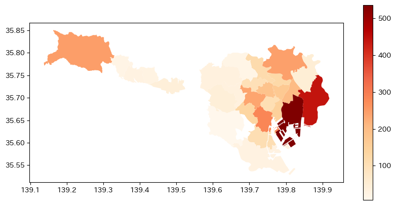

```python
gdf_tokyo_stops.plot(column='stop_id', cmap='OrRd', figsize=(10, 5), legend=True)
```